# History of Philosophy: Which school should we spend most time studying?

Contributor: Yuxin Liang, UNI: YL5140

[figure not shown]

## Introduction

In this project, I aim to find the school that is most worthy to spend time studying of philosophy from the data set we have. Then I want to see which word is most likely to occur in this school. In order to find it, I want to ask myself which school last for the most years and which one has most authors contributed to it. By combining the results of the first two questions, I would find the union of the first five longest-duration and the most popular five schools. Then, I would clean the data to include only the union of the result schools. After that, I want to use the sentences provided to find what is the word that is most likely to be seen for each school respectively so that we can have a little more information about them.

## R-packages used

– “tidyverse”  
– “haven”  
– “devtools”  
– “RColorBrewer”  
– “data.table”  
– “ggplot2”  
– “forcats”  
– “vcd”  
– “gridExtra”  
– “HH”  
– “GGally”  
– “readr”  
– “knitr”  
– “markdown”  
– “here”  
– “dplyr” – “stopwords” – “hcandersenr” – “tidytext”

## Data

```r
library(haven)
phi <- read_csv("../data/philosophy_data.csv")
```

– This is the first five lines of the data set. This gives me a general idea of what is inside the data set.

```r
head(phi, 5)
```

| title | author | school | sentence_spacy | sentence_str | original_publication_date | corpus_edition_date | sentence_length | sentence_lowered | tokenized_txt | lemmatized_str |
| --- | --- | --- | --- | --- | --- | --- | --- | --- | --- | --- |
| Plato - Complete Works | Plato | plato | What's new, Socrates, to make you leave your usual haunts in the Lyceum and spend your time here by the king archon's court? | What's new, Socrates, to make you leave your usual haunts in the Lyceum and spend your time here by the king archon's court? | -350 | 1997 | 125 | what's new, socrates, to make you leave your usual haunts in the lyceum and spend your time here by the king archon's court? | ['what', 'new', 'socrates', 'to', 'make', 'you', 'leave', 'your', 'usual', 'haunts', 'in', 'the', 'lyceum', 'and', 'spend', 'your', 'time', 'here', 'by', 'the', 'king', 'archon', 'court'] | what be new , Socrates , to make -PRON- leave -PRON- usual haunt in the Lyceum and spend -PRON- time here by the king archon 's court ? |
| Plato - Complete Works | Plato | plato | Surely you are not prosecuting anyone before the king archon as I am? | Surely you are not prosecuting anyone before the king archon as I am? | -350 | 1997 | 69 | surely you are not prosecuting anyone before the king archon as i am? | ['surely', 'you', 'are', 'not', 'prosecuting', 'anyone', 'before', 'the', 'king', 'archon', 'as', 'am'] | surely -PRON- be not prosecute anyone before the king archon as -PRON- be ? |
| Plato - Complete Works | Plato | plato | The Athenians do not call this a prosecution but an indictment, Euthyphro. | The Athenians do not call this a prosecution but an indictment, Euthyphro. | -350 | 1997 | 74 | the athenians do not call this a prosecution but an indictment, euthyphro. | ['the', 'athenians', 'do', 'not', 'call', 'this', 'prosecution', 'but', 'an', 'indictment', 'euthyphro'] | the Athenians do not call this a prosecution but an indictment , Euthyphro . |
| Plato - Complete Works | Plato | plato | What is this you say? | What is this you say? | -350 | 1997 | 21 | what is this you say? | ['what', 'is', 'this', 'you', 'say'] | what be this -PRON- say ? |
| Plato - Complete Works | Plato | plato | Someone must have indicted you, for you are not going to tell me that you have indicted someone else. | Someone must have indicted you, for you are not going to tell me that you have indicted someone else. | -350 | 1997 | 101 | someone must have indicted you, for you are not going to tell me that you have indicted someone else. | ['someone', 'must', 'have', 'indicted', 'you', 'for', 'you', 'are', 'not', 'going', 'to', 'tell', 'me', 'that', 'you', 'have', 'indicted', 'someone', 'else'] | someone must have indict -PRON- , for -PRON- be not go to tell -PRON- that -PRON- have indict someone else . |

## Questions

[figure not shown]

### 1. Which school exist for the longest time?

First, I want to see which school last for the longest time.  
To do that, I want to find the smallest year and maximum year for each school (use “original_publication_date”) and then use subtraction to find the duration.

– This is the plot of the duration of each school. As the plot shows the first five schools with longest duration are “Feminism”, “Capitalism”, “Empiricism”, “Analytic”, and “Rationalism”.

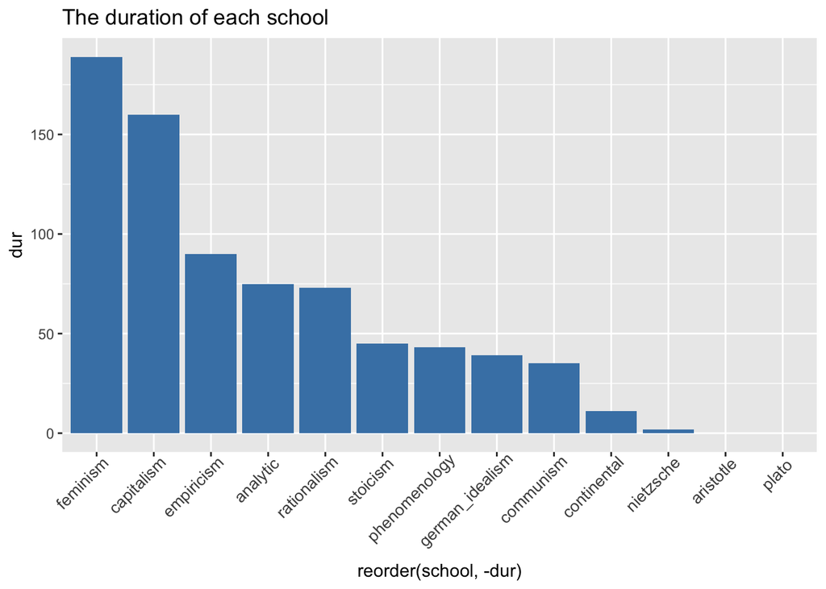

```r
ggplot(data=by.school1, aes(x=reorder(school,-dur), y=dur)) +
  geom_bar(stat="identity",
                 fill="steelblue")+
  labs(title="The duration of each school")+
  theme(axis.text.x = element_text(angle=45, hjust=0.9, size = 10))
```

– After rearrange the data set in descending form, the first five schools in the data set matches my plot above.

```r
head(by.school1,5)
```

| school | min.year | max.year | dur |
| --- | --- | --- | --- |
| feminism | 1792 | 1981 | 189 |
| capitalism | 1776 | 1936 | 160 |
| empiricism | 1689 | 1779 | 90 |
| analytic | 1910 | 1985 | 75 |
| rationalism | 1637 | 1710 | 73 |

### 2. Which school has most authors contributed to it?

Now, I want to see which school has most authors to decide if it is a popular one. I would choose the most three popular schools and compare the results with those of the previous one.

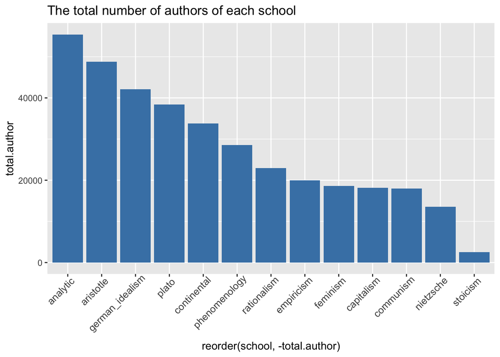

```r
ggplot(data=by.school2, aes(x=reorder(school,-total.author), y=total.author)) +
  geom_bar(stat="identity",
                 fill="steelblue")+
  labs(title="The total number of authors of each school")+
  theme(axis.text.x = element_text(angle=45, hjust=0.9, size = 10))
```

```r
head(by.school1,5)
```

[output not shown]

### Analyze my first two results

From what I got above  
– The schools with longest duration are “Feminism”, “Capitalism”, “Empiricism”, “Analytic”, and “Rationalism”.  
– The schools with most authors contributed to them are “Analytic”, “Aristotle”, “German_idealism”, “Plato”, and “Continental”.  
I want to find the overlap of the two results because that would be the schools with both long duration and a lot of authors. Therefore, those schools are the ones that people should pay more attention to. As I presented, the only school that exist in both sets is “Analytic”. Therefore, I would use only data of “Analytic” in my next question to find the word that is most likely to present in this school.

### 3. Among the school that is most study-worthy, what are words that are most likely to appear?

After I find the school that I want to focus on, I want to see the mostly appeared word. To do that, I would first select needed data from the data set. Then I will remove stop words from the sentences in the data and then find out the first five mostly occurred words.

– As shown below, the first five words that are most frequently occurred are “true”, “sense”, “theory”, “language” and “time”.

```r
words <- sort(table(phi.ana.tok),decreasing=TRUE)
head(words,5)
```

```
## word
##     true    sense   theory language     time
##     3055     2518     2138     1853     1815
```

[figure not shown]